```python
import numpy as np
import matplotlib.pyplot as plt
from mpl_toolkits.mplot3d import Axes3D
import scipy.linalg as la
```

# Advanced Linear Algebra: SVD, Orthogonal Matrices, and Eigendecomposition

## 1. Singular Value Decomposition (SVD)

### Mathematical Foundation

The Singular Value Decomposition is a factorization of a matrix $A$ into the product of three matrices:

$A = U\Sigma V^T$

where:

- $U$ is an $m \times m$ orthogonal matrix
- $\Sigma$ is an $m \times n$ diagonal matrix with non-negative real numbers
- $V^T$ is the transpose of an $n \times n$ orthogonal matrix $V$

The diagonal entries $\sigma_i$ of $\Sigma$ are called singular values.

### Geometric Interpretation

SVD decomposes any linear transformation into three steps:

1. Rotation/reflection ($V^T$)
2. Scaling along coordinate axes ($\Sigma$)
3. Another rotation/reflection ($U$)

Let's visualize this decomposition:

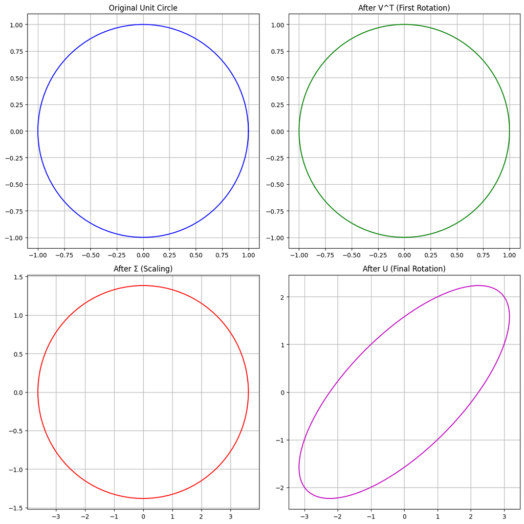

```python
def visualize_svd():
    # Create a matrix
    A = np.array([[3, 1], [1, 2]])

    # Compute SVD
    U, s, Vt = np.linalg.svd(A)

    # Create points for visualization
    theta = np.linspace(0, 2*np.pi, 100)
    circle_x = np.cos(theta)
    circle_y = np.sin(theta)
    points = np.vstack((circle_x, circle_y))

    # Apply transformations step by step
    step1 = Vt @ points
    step2 = np.diag(s) @ step1
    step3 = U @ step2

    # Plotting
    fig, ((ax1, ax2), (ax3, ax4)) = plt.subplots(2, 2, figsize=(12, 12))

    # Original circle
    ax1.plot(points[0], points[1], 'b-')
    ax1.grid(True)
    ax1.set_title('Original Unit Circle')

    # After V^T (rotation)
    ax2.plot(step1[0], step1[1], 'g-')
    ax2.grid(True)
    ax2.set_title('After V^T (First Rotation)')

    # After Σ (scaling)
    ax3.plot(step2[0], step2[1], 'r-')
    ax3.grid(True)
    ax3.set_title('After Σ (Scaling)')

    # After U (final rotation)
    ax4.plot(step3[0], step3[1], 'm-')
    ax4.grid(True)
    ax4.set_title('After U (Final Rotation)')

    plt.tight_layout()
    plt.show()

    return U, s, Vt

U, s, Vt = visualize_svd()
```

### Why is SVD Useful?

1. **Matrix Approximation**
   - SVD allows for low-rank approximations by keeping only the largest singular values
   - This is crucial in data compression and dimensionality reduction
2. **Principal Component Analysis (PCA)**
   - SVD is directly related to PCA
   - The right singular vectors ($V$) are the principal components
   - The singular values tell us how important each component is
3. **Pseudoinverse Computation**
   - The pseudoinverse can be easily computed using SVD
   - This is useful for solving least squares problems
4. **Condition Number**
   - The ratio of largest to smallest singular values gives the condition number
   - This tells us how well-conditioned a matrix is

Let's implement some of these applications:

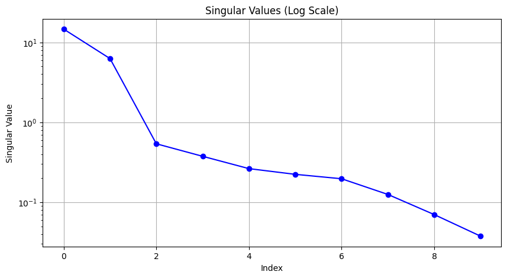

```python
def svd_applications():
    # Create a noisy matrix
    true_rank = 2
    n = 10
    true_data = np.random.randn(n, true_rank) @ np.random.randn(true_rank, n)
    noise = 0.1 * np.random.randn(n, n)
    A = true_data + noise

    # Compute SVD
    U, s, Vt = np.linalg.svd(A)

    # Low rank approximation
    r = 2  # rank of approximation
    A_approx = U[:, :r] @ np.diag(s[:r]) @ Vt[:r, :]

    # Compute errors
    error = np.linalg.norm(A - A_approx, 'fro')
    condition_number = s[0] / s[-1]

    # Plotting singular values
    plt.figure(figsize=(10, 5))
    plt.semilogy(s, 'bo-')
    plt.grid(True)
    plt.title('Singular Values (Log Scale)')
    plt.xlabel('Index')
    plt.ylabel('Singular Value')
    plt.show()

    return error, condition_number

error, cond = svd_applications()
```

## 2. Orthogonal/Orthonormal Matrices

### Mathematical Definition

A matrix $Q$ is orthogonal if: $Q^TQ = QQ^T = I$

This means:

1. Its columns are orthonormal (perpendicular and unit length)
2. Its inverse equals its transpose: $Q^{-1} = Q^T$

### Why are Orthonormal Bases Special?

1. **Preservation of Inner Products**
   - Orthogonal transformations preserve distances and angles
   - $\\|Qv\\| = \\|v\\|$ for any vector $v$
2. **Computational Efficiency**
   - No need to compute inverse (just transpose)
   - Better numerical stability
3. **Geometric Interpretation**
   - Represents pure rotations and reflections
   - No scaling or shearing involved

Let's visualize these properties:

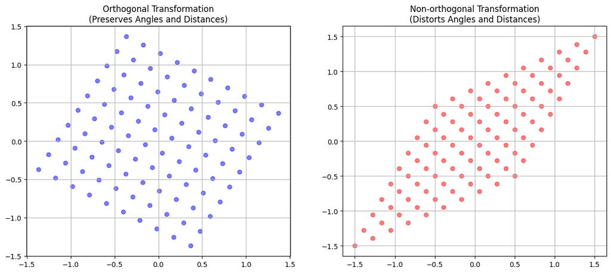

```python
def demonstrate_orthogonal_properties():
    # Create an orthogonal matrix (rotation)
    theta = np.pi/3
    Q = np.array([[np.cos(theta), -np.sin(theta)],
                  [np.sin(theta), np.cos(theta)]])

    # Create a regular non-orthogonal basis
    A = np.array([[1, 0.5],
                  [0.5, 1]])

    # Create points for visualization
    x = np.linspace(-1, 1, 10)
    y = np.linspace(-1, 1, 10)
    X, Y = np.meshgrid(x, y)
    points = np.column_stack((X.flatten(), Y.flatten()))

    # Apply transformations
    orthogonal_transform = points @ Q.T
    regular_transform = points @ A.T

    fig, (ax1, ax2) = plt.subplots(1, 2, figsize=(15, 6))

    # Plot orthogonal transformation
    ax1.scatter(orthogonal_transform[:, 0], orthogonal_transform[:, 1], c='b', alpha=0.5)
    ax1.grid(True)
    ax1.set_title('Orthogonal Transformation\n(Preserves Angles and Distances)')

    # Plot regular transformation
    ax2.scatter(regular_transform[:, 0], regular_transform[:, 1], c='r', alpha=0.5)
    ax2.grid(True)
    ax2.set_title('Non-orthogonal Transformation\n(Distorts Angles and Distances)')

    plt.show()

    return Q, A

Q, A = demonstrate_orthogonal_properties()
```

## 3. Eigenvalues and Eigenvectors

### Mathematical Definition

For a square matrix $A$, an eigenvector $v$ and corresponding eigenvalue $\lambda$ satisfy:

$Av = \lambda v$

This means that applying the transformation $A$ to $v$ only scales $v$ by $\lambda$.

### Geometric Interpretation

1. **Invariant Directions**
   - Eigenvectors represent directions that are only scaled (not rotated) by the transformation
   - The eigenvalue tells us the amount of scaling
2. **Classification of Linear Transformations**
   - Real positive eigenvalues: stretching/compression
   - Negative eigenvalues: reflection and scaling
   - Complex eigenvalues: rotation with scaling

Let's visualize these concepts:

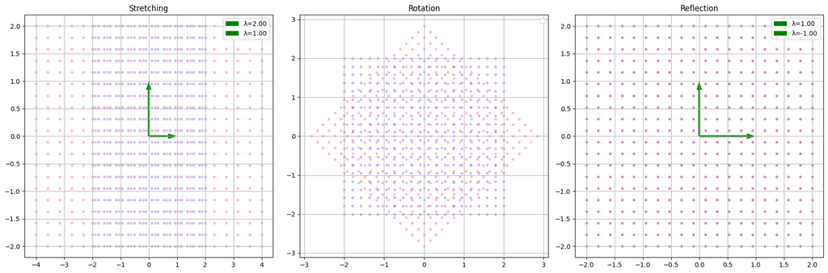

```python
def visualize_eigenvectors():
    # Create matrices with different types of eigenvalues
    # Stretching
    A1 = np.array([[2, 0],
                   [0, 1]])
    # Rotation
    theta = np.pi/4
    A2 = np.array([[np.cos(theta), -np.sin(theta)],
                   [np.sin(theta), np.cos(theta)]])
    # Reflection
    A3 = np.array([[1, 0],
                   [0, -1]])

    matrices = [A1, A2, A3]
    titles = ['Stretching', 'Rotation', 'Reflection']

    fig, axes = plt.subplots(1, 3, figsize=(18, 6))

    for ax, A, title in zip(axes, matrices, titles):
        # Compute eigenvectors and eigenvalues
        eigvals, eigvecs = np.linalg.eig(A)

        # Create grid of points
        x = np.linspace(-2, 2, 20)
        y = np.linspace(-2, 2, 20)
        X, Y = np.meshgrid(x, y)
        points = np.column_stack((X.flatten(), Y.flatten()))

        # Transform points
        transformed = points @ A.T

        # Plot
        ax.scatter(points[:, 0], points[:, 1], c='b', alpha=0.2, s=10)
        ax.scatter(transformed[:, 0], transformed[:, 1], c='r', alpha=0.2, s=10)

        # Plot eigenvectors if real
        for i in range(len(eigvals)):
            if np.isreal(eigvals[i]):
                v = eigvecs[:, i]
                ax.quiver(0, 0, v[0], v[1], angles='xy', scale_units='xy',
                         scale=1, color='g', label=f'λ={eigvals[i]:.2f}')

        ax.grid(True)
        ax.set_title(title)
        ax.legend()

    plt.tight_layout()
    plt.show()

visualize_eigenvectors()
```

### Applications of Eigendecomposition

1. **Diagonalization**
   - If $A$ has $n$ linearly independent eigenvectors, then:
   - $A = PDP^{-1}$ where $D$ is diagonal matrix of eigenvalues
   - This makes computing powers of $A$ very efficient
2. **Dynamical Systems**
   - Eigenvalues determine long-term behavior
   - Positive eigenvalues: exponential growth
   - Negative eigenvalues: exponential decay
   - Complex eigenvalues: oscillatory behavior
3. **Principal Component Analysis**
   - Eigenvectors of covariance matrix are principal components
   - Eigenvalues represent variance explained by each component

Let's implement some applications:

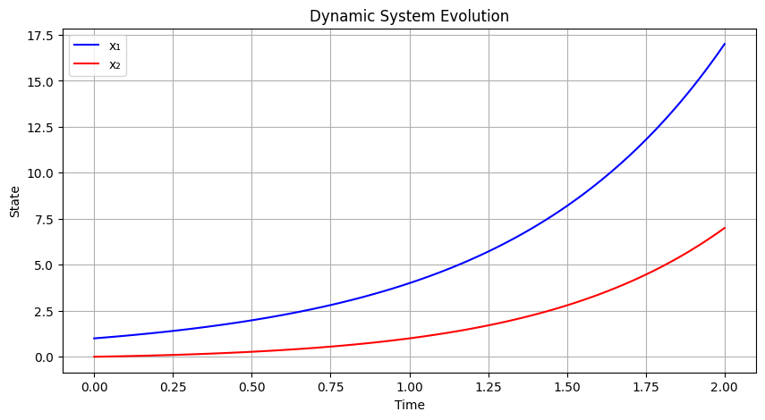

```python
def eigenvalue_applications():
    # Create a matrix
    A = np.array([[4, 1],
                  [1, 3]])

    # Compute eigendecomposition
    eigvals, eigvecs = np.linalg.eig(A)

    # Diagonalization
    D = np.diag(eigvals)
    P = eigvecs
    A_reconstructed = P @ D @ np.linalg.inv(P)

    # Compute powers efficiently
    def matrix_power(A, n):
        eigvals, P = np.linalg.eig(A)
        return P @ np.diag(eigvals**n) @ np.linalg.inv(P)

    # Dynamic system simulation
    t = np.linspace(0, 2, 100)
    x0 = np.array([1, 0])
    trajectories = np.zeros((len(t), 2))

    for i, ti in enumerate(t):
        trajectories[i] = matrix_power(A, ti) @ x0

    plt.figure(figsize=(10, 5))
    plt.plot(t, trajectories[:, 0], 'b-', label='x₁')
    plt.plot(t, trajectories[:, 1], 'r-', label='x₂')
    plt.grid(True)
    plt.title('Dynamic System Evolution')
    plt.xlabel('Time')
    plt.ylabel('State')
    plt.legend()
    plt.show()

    return eigvals, eigvecs

eigvals, eigvecs = eigenvalue_applications()
```

## Key Insights and Connections

1. **SVD vs Eigendecomposition**
   - SVD works for any matrix; eigendecomposition only for square matrices
   - SVD singular values are always real and non-negative
   - SVD is more stable numerically
   - Both reveal fundamental structure of linear transformations
2. **Orthogonal Matrices and SVD**
   - $U$ and $V$ in SVD are orthogonal
   - This makes SVD particularly useful for numerical computations
   - Preserves numerical stability in computations
3. **Applications in Machine Learning**
   - PCA uses eigendecomposition of covariance matrix
   - SVD is used in recommender systems
   - Orthogonal matrices preserve distances, important in deep learning